# 1st Chilean Summer School about Social Network Research – January 2024

*The Chilean Society for Social Network Science (ChiSocNet)*

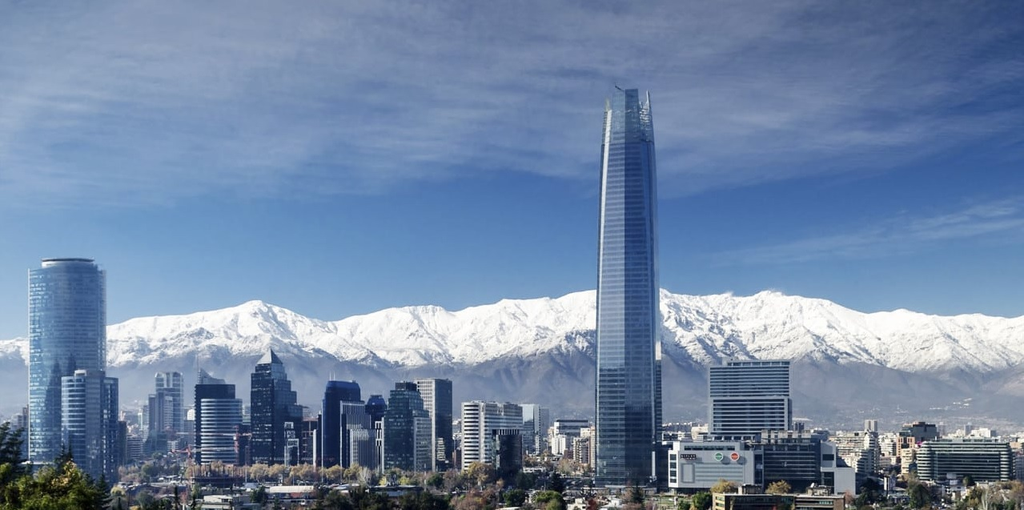

Picture by Joaquin Bruna ([Wikimedia commons](https://commons.wikimedia.org/wiki/File:Santiago_de_Chile_%28winter%29.jpg))

## Course objectives

By the end of the week, participants would be able to design social network research, collect network data from classical to digital information, describe and visualise networks, and perform statistical models using social networks (e.g., ERGM and RSIENA). They will also have an overview of the most relevant topics about social networks. During the week, participants would have lectures and practical experience in using the R software and engage in practical experience through group projects.

The course will:

- Introduce the idea of social network research.
- Explain how to collect, describe and visualise networks.
- Explain how to model social networks.
- Provide hands-on training to use R to investigate social networks.

## Timeline

2nd October 2023: Deadline submission applications

20th October 2023: New Deadline submission applications

6th November 2023: Notifications

13th November - 4th December 2023: Registration

**8-12 January 2024: Summer School**

## Participation fee

Flatrate of CLP 150,000 p.p. (approx. 190 US Dollars)

## Application

To apply, please send a motivation letter (stating your research background, research interests, and reasons to learn about network methods) and a short CV to chisocnet@gmail.com (by 2nd October 2023).

## Location

Institute of Sociology, Pontifical Catholic University of Chile. Avenida Vicuña Mackenna 4860, Macul, Santiago

## Contact

Alejandro Espinosa-Rada  
Social Networks Lab, ETH Zürich  
chisocnet@gmail.com

## Sponsors

- Institute of Sociology, Pontifical Catholic University of Chile.